# Prediction Assignment Writeup

Olga Maria Serrano Ramos

November, 2014

## Background

Using devices such as Jawbone Up, Nike FuelBand, and Fitbit it is now possible to collect a large amount of data about personal activity relatively inexpensively. These type of devices are part of the quantified self movement  a group of enthusiasts who take measurements about themselves regularly to improve their health, to find patterns in their behavior, or because they are tech geeks. One thing that people regularly do is quantify how much of a particular activity they do, but they rarely quantify how well they do it. In this project, your goal will be to use data from accelerometers on the belt, forearm, arm, and dumbell of 6 participants. They were asked to perform barbell lifts correctly and incorrectly in 5 different ways. More information is available from the website here: http://groupware.les.inf.puc-rio.br/har (see the section on the Weight Lifting Exercise Dataset).

## Data

The training data for this project are available here:

https://d396qusza40orc.cloudfront.net/predmachlearn/pml-training.csv

The test data are available here:

https://d396qusza40orc.cloudfront.net/predmachlearn/pml-testing.csv

The data for this project come from this source: http://groupware.les.inf.puc-rio.br/har. If you use the document you create for this class for any purpose please cite them as they have been very generous in allowing their data to be used for this kind of assignment.

## What you should submit

The goal of your project is to predict the manner in which they did the exercise. This is the “classe” variable in the training set. You may use any of the other variables to predict with. You should create a report describing how you built your model, how you used cross validation, what you think the expected out of sample error is, and why you made the choices you did. You will also use your prediction model to predict 20 different test cases.

1. Your submission should consist of a link to a Github repo with your R markdown and compiled HTML file describing your analysis. Please constrain the text of the writeup to < 2000 words and the number of figures to be less than 5. It will make it easier for the graders if you submit a repo with a gh-pages branch so the HTML page can be viewed online (and you always want to make it easy on graders :-).
2. You should also apply your machine learning algorithm to the 20 test cases available in the test data above. Please submit your predictions in appropriate format to the programming assignment for automated grading. See the programming assignment for additional details.

## Reproducibility

Due to security concerns with the exchange of R code, your code will not be run during the evaluation by your classmates. Please be sure that if they download the repo, they will be able to view the compiled HTML version of your analysis.

## Reading and Separating testing Data

```r
library(caret)
set.seed(123)
ftraining <- read.csv("./Data/pml-training.csv",na.strings = c("NA", ""))
ftesting <- read.csv("./Data/pml-testing.csv",na.strings = c("NA", ""))

inTrain = createDataPartition(ftraining$classe, p = 0.75, list = F)
ctraining = ftraining[inTrain,]
ctesting  = ftraining[-inTrain,]
```

## cleaning data

### cleaning NAS

```r
listtraining=(colSums(is.na(ctraining)) == 0)
listtrainingMatrix=as.matrix(listtraining)
namesCleaned=names(listtrainingMatrix[listtrainingMatrix[,1]==TRUE,])

ctraining <- ctraining[, (colSums(is.na(ctraining)) == 0)]
ctesting=ctesting[ , which(names(ctesting) %in% namesCleaned)]

ctraining = ctraining[,8:60]
ctesting <-ctesting[,8:60]
```

### cleaning higestCorrs

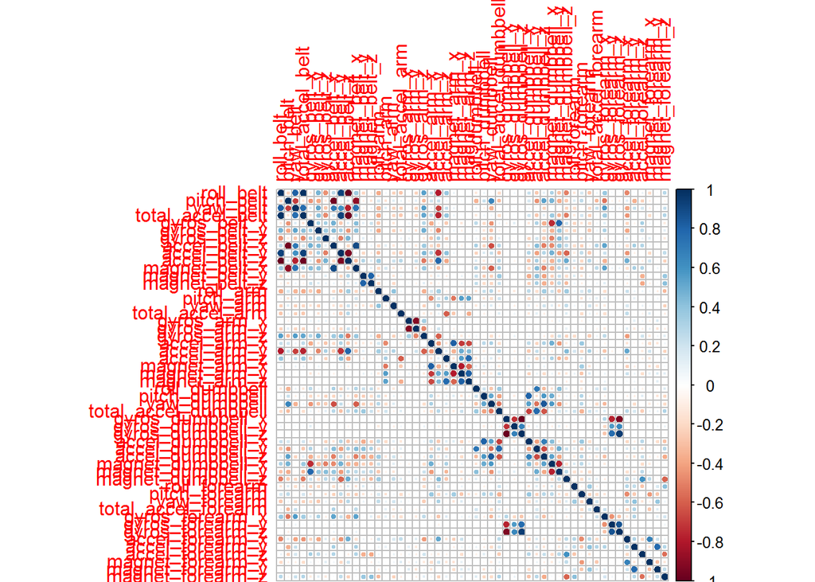

```r
nums <- sapply(ctraining, is.numeric)
d= ctraining[ , nums]
corrMatrix=as.matrix(cor(d))
library('corrplot')
corrplot(corrMatrix, method = "circle")
```

```r
highCorrCols=findCorrelation(corrMatrix, cutoff = .90)
highCorrFeatures = names(ctraining)[highCorrCols]
ctraining = ctraining[,-highCorrCols]
ctesting = ctesting[,-highCorrCols]
```

### Same classes for each dataframe

```r
class(ctesting[1:46]) <- class(ctraining[1:46])
rtesting = ctesting ## dataframe to compare results
ctesting = ctesting[,-46] ## data frame to test
```

## Testing modeling k-Nearest Neighbors.

```r
ctrl = trainControl(method = "adaptive_cv")
model1_KNN = train(classe ~ ., ctraining, method = "knn", trControl = ctrl)
model1_KNN
```

```
## k-Nearest Neighbors
##
## 14718 samples
##    45 predictor
##     5 classes: 'A', 'B', 'C', 'D', 'E'
##
## No pre-processing
## Resampling: Adaptively Cross-Validated (10 fold, repeated 1 times)
##
## Summary of sample sizes: 13247, 13246, 13247, 13246, 13245, 13246, ...
##
## Resampling results across tuning parameters:
##
##   k  Accuracy  Kappa  Accuracy SD  Kappa SD  .B
##   5  0.9       0.9    0.008        0.010     10
##   7  0.9       0.9    0.009        0.011      5
##   9  0.9       0.8    0.006        0.007      5
##
## Accuracy was used to select the optimal model using  the largest value.
## The final value used for the model was k = 5.
```

```r
pred <- predict(model1_KNN, newdata=ctesting)
confusionMatrix(pred, rtesting$classe)
```

```
## Confusion Matrix and Statistics
##
##           Reference
## Prediction    A    B    C    D    E
##          A 1342   41   17   11   13
##          B   15  837   27    4   34
##          C   12   33  783   72   28
##          D   25   20   13  707   29
##          E    1   18   15   10  797
##
## Overall Statistics
##
##                Accuracy : 0.911
##                  95% CI : (0.902, 0.919)
##     No Information Rate : 0.284
##     P-Value [Acc > NIR] : <2e-16
##
##                   Kappa : 0.887
##  Mcnemar's Test P-Value : <2e-16
##
## Statistics by Class:
##
##                      Class: A Class: B Class: C Class: D Class: E
## Sensitivity             0.962    0.882    0.916    0.879    0.885
## Specificity             0.977    0.980    0.964    0.979    0.989
## Pos Pred Value          0.942    0.913    0.844    0.890    0.948
## Neg Pred Value          0.985    0.972    0.982    0.976    0.974
## Prevalence              0.284    0.194    0.174    0.164    0.184
## Detection Rate          0.274    0.171    0.160    0.144    0.163
## Detection Prevalence    0.290    0.187    0.189    0.162    0.171
## Balanced Accuracy       0.969    0.931    0.940    0.929    0.937
```

## Testing modeling randomForest.

### Accuracy : 0.9912

```r
ctrl = trainControl(method = "oob")
model2_RF = train(classe ~ ., ctraining, method = "rf", ntree = 200, trControl = ctrl)
model2_RF
```

```
## Random Forest
##
## 14718 samples
##    45 predictor
##     5 classes: 'A', 'B', 'C', 'D', 'E'
##
## No pre-processing
## Resampling: Out of Bag Resampling
##
## Summary of sample sizes:
##
## Resampling results across tuning parameters:
##
##   mtry  Accuracy  Kappa
##    2    1         1
##   23    1         1
##   45    1         1
##
## Accuracy was used to select the optimal model using  the largest value.
## The final value used for the model was mtry = 2.
```

```r
pred <- predict(model2_RF, newdata=ctesting)
confusionMatrix(pred, rtesting$classe)
```

```
## Confusion Matrix and Statistics
##
##           Reference
## Prediction    A    B    C    D    E
##          A 1394    3    0    1    0
##          B    1  944    7    0    0
##          C    0    2  847   18    0
##          D    0    0    1  783    2
##          E    0    0    0    2  899
##
## Overall Statistics
##
##                Accuracy : 0.992
##                  95% CI : (0.99, 0.995)
##     No Information Rate : 0.284
##     P-Value [Acc > NIR] : <2e-16
##
##                   Kappa : 0.99
##  Mcnemar's Test P-Value : NA
##
## Statistics by Class:
##
##                      Class: A Class: B Class: C Class: D Class: E
## Sensitivity             0.999    0.995    0.991    0.974    0.998
## Specificity             0.999    0.998    0.995    0.999    1.000
## Pos Pred Value          0.997    0.992    0.977    0.996    0.998
## Neg Pred Value          1.000    0.999    0.998    0.995    1.000
## Prevalence              0.284    0.194    0.174    0.164    0.184
## Detection Rate          0.284    0.192    0.173    0.160    0.183
## Detection Prevalence    0.285    0.194    0.177    0.160    0.184
## Balanced Accuracy       0.999    0.996    0.993    0.987    0.999
```

## Random Forest is selected to write solution

### firstable clean ftesting

```r
ftesting <- read.csv("./Data/pml-testing.csv",na.strings = c("NA", ""))
ftesting=ftesting[ , which(names(ftesting) %in% namesCleaned)]
ftesting <-ftesting[,8:59]
ftesting = ftesting[,-highCorrCols]
class(ftesting[1:45]) <- class(ctraining[1:45])


pred <- predict(model2_RF, newdata=ftesting)
pred
```

```
##  [1] B A B A A E D B A A B C B A E E A B B B
## Levels: A B C D E
```

### write submision files

```r
  for(i in 1:length(pred)){
    filename = paste0("./submit/sol_",i,".txt")
    write.table(pred[i],file=filename,quote=FALSE,row.names=FALSE,col.names=FALSE)
  }
```